```python
import numpy as np # library to handle data in a vectorized manner

import pandas as pd # library for data analsysis
pd.set_option('display.max_columns', None)
pd.set_option('display.max_rows', None)

import json # library to handle JSON files

!conda install -c conda-forge geopy --yes # uncomment this line if you haven't completed the Foursquare API lab
from geopy.geocoders import Nominatim # convert an address into latitude and longitude values

import requests # library to handle requests
from pandas.io.json import json_normalize # tranform JSON file into a pandas dataframe

# Matplotlib and associated plotting modules
import matplotlib.cm as cm
import matplotlib.colors as colors

# import k-means from clustering stage
from sklearn.cluster import KMeans

#!conda install -c conda-forge folium=0.5.0 --yes # uncomment this line if you haven't completed the Foursquare API lab
import folium # map rendering library
print('Libraries imported.')
```

[output not shown]

# Capstone Project - The Battle of the Neighborhoods

### Applied Data Science Capstone by IBM/Coursera

#### *M.HARINI*

- Introduction
- Data
- Methodology
- Analysis
- Results and Discussion
- Conclusion

### * Introduction

This report analyses to find the best location and features for starting a Chinese Restaurant in Chennai,a city in Southern State of India. we will try finding neighborhood which is not crowded with many restaurants and also analyse features that are missing in other restaurants like analysing the number of restaurants with online delivery and neighborhoods with less delivery rating rate and less average rating rate.

#### * Data

we will be using Foursquare location data to map the clustering of the restaurants in a neighborhood and also to get the top venues in each neighborhood like what is the top visited venues in each locality. we will also be using the Zomato Restaurant data to get the details of the restaurants in each neighborhood their average rating, price, latitude,longitude,location and etc. we will refine the dataset so that it contains only relevant information.

```python
df = pd.read_csv('https://raw.githubusercontent.com/haanjiankur/Capstone-Project---The-Battle-of-Neighborhoods/master/zomato.csv',encoding='ISO-8859-1')
df.head()
```

|  | Restaurant ID | Restaurant Name | Country Code | City | Address | Locality | Locality Verbose | Longitude | Latitude | Cuisines | Average Cost for two | Currency | Has Table booking | Has Online delivery | Is delivering now | Switch to order menu | Price range | Aggregate rating | Rating color | Rating text | Votes |
| --- | --- | --- | --- | --- | --- | --- | --- | --- | --- | --- | --- | --- | --- | --- | --- | --- | --- | --- | --- | --- | --- |
| 0 | 6317637 | Le Petit Souffle | 162 | Makati City | Third Floor, Century City Mall, Kalayaan Avenu... | Century City Mall, Poblacion, Makati City | Century City Mall, Poblacion, Makati City, Mak... | 121.027535 | 14.565443 | French, Japanese, Desserts | 1100 | Botswana Pula(P) | Yes | No | No | No | 3 | 4.8 | Dark Green | Excellent | 314 |
| 1 | 6304287 | Izakaya Kikufuji | 162 | Makati City | Little Tokyo, 2277 Chino Roces Avenue, Legaspi... | Little Tokyo, Legaspi Village, Makati City | Little Tokyo, Legaspi Village, Makati City, Ma... | 121.014101 | 14.553708 | Japanese | 1200 | Botswana Pula(P) | Yes | No | No | No | 3 | 4.5 | Dark Green | Excellent | 591 |
| 2 | 6300002 | Heat - Edsa Shangri-La | 162 | Mandaluyong City | Edsa Shangri-La, 1 Garden Way, Ortigas, Mandal... | Edsa Shangri-La, Ortigas, Mandaluyong City | Edsa Shangri-La, Ortigas, Mandaluyong City, Ma... | 121.056831 | 14.581404 | Seafood, Asian, Filipino, Indian | 4000 | Botswana Pula(P) | Yes | No | No | No | 4 | 4.4 | Green | Very Good | 270 |
| 3 | 6318506 | Ooma | 162 | Mandaluyong City | Third Floor, Mega Fashion Hall, SM Megamall, O... | SM Megamall, Ortigas, Mandaluyong City | SM Megamall, Ortigas, Mandaluyong City, Mandal... | 121.056475 | 14.585318 | Japanese, Sushi | 1500 | Botswana Pula(P) | No | No | No | No | 4 | 4.9 | Dark Green | Excellent | 365 |
| 4 | 6314302 | Sambo Kojin | 162 | Mandaluyong City | Third Floor, Mega Atrium, SM Megamall, Ortigas... | SM Megamall, Ortigas, Mandaluyong City | SM Megamall, Ortigas, Mandaluyong City, Mandal... | 121.057508 | 14.584450 | Japanese, Korean | 1500 | Botswana Pula(P) | Yes | No | No | No | 4 | 4.8 | Dark Green | Excellent | 229 |

```python
df_india = df[df['Country Code'] == 1]
df_tn = df_india[df_india['City'] == 'Chennai']
df_tn.reset_index(drop=True, inplace=True)
df_tn.head()
```

|  | Restaurant ID | Restaurant Name | Country Code | City | Address | Locality | Locality Verbose | Longitude | Latitude | Cuisines | Average Cost for two | Currency | Has Table booking | Has Online delivery | Is delivering now | Switch to order menu | Price range | Aggregate rating | Rating color | Rating text | Votes |
| --- | --- | --- | --- | --- | --- | --- | --- | --- | --- | --- | --- | --- | --- | --- | --- | --- | --- | --- | --- | --- | --- |
| 0 | 69024 | That Madras Place | 1 | Chennai | 34/29, 2nd Main Road, Kasturibai Nagar, Adyar,... | Adyar | Adyar, Chennai | 80.250744 | 13.005801 | European, Italian, Desserts | 800 | Indian Rupees(Rs.) | Yes | Yes | No | No | 2 | 4.2 | Green | Very Good | 1810 |
| 1 | 72475 | Haunted | 1 | Chennai | 273, F13, New Number 71, 2nd Main Road, Anna N... | Anna Nagar East | Anna Nagar East, Chennai | 80.220672 | 13.086438 | North Indian, Chinese, Arabian | 800 | Indian Rupees(Rs.) | Yes | Yes | No | No | 2 | 3.8 | Yellow | Good | 519 |
| 2 | 70431 | Pantry d'or | 1 | Chennai | 21/11, J Block, 6th Avenue Main Road, Anna Nag... | Anna Nagar East | Anna Nagar East, Chennai | 80.219104 | 13.091809 | Continental, Cafe, Italian, Desserts | 750 | Indian Rupees(Rs.) | Yes | Yes | No | No | 2 | 4.4 | Green | Very Good | 1504 |
| 3 | 71443 | Palmshore | 1 | Chennai | 95, Jawaharlal Nehru Salai, Jafferkhanpet, Ash... | Ashok Nagar | Ashok Nagar, Chennai | 80.208812 | 13.029780 | North Indian, Mughlai, Chinese, South Indian | 850 | Indian Rupees(Rs.) | Yes | Yes | No | No | 2 | 4.2 | Green | Very Good | 841 |
| 4 | 73088 | Chili's | 1 | Chennai | 49 & 50 L, Express Avenue Mall, White's Road, ... | Express Avenue Mall, Royapettah | Express Avenue Mall, Royapettah, Chennai | 80.264151 | 13.058616 | Mexican, American, Tex-Mex, Burger | 1700 | Indian Rupees(Rs.) | Yes | Yes | No | No | 3 | 4.8 | Dark Green | Excellent | 1262 |

```python
df_tn_1= df_tn[df_tn.Longitude !=0.000000][['Restaurant Name','Locality','Longitude','Latitude','Cuisines','Aggregate rating','Rating text','Votes','Average Cost for two','Has Online delivery']]
```

```python
df_tn_1.head()
```

|  | Restaurant Name | Locality | Longitude | Latitude | Cuisines | Aggregate rating | Rating text | Votes | Average Cost for two | Has Online delivery |
| --- | --- | --- | --- | --- | --- | --- | --- | --- | --- | --- |
| 0 | That Madras Place | Adyar | 80.250744 | 13.005801 | European, Italian, Desserts | 4.2 | Very Good | 1810 | 800 | Yes |
| 1 | Haunted | Anna Nagar East | 80.220672 | 13.086438 | North Indian, Chinese, Arabian | 3.8 | Good | 519 | 800 | Yes |
| 2 | Pantry d'or | Anna Nagar East | 80.219104 | 13.091809 | Continental, Cafe, Italian, Desserts | 4.4 | Very Good | 1504 | 750 | Yes |
| 3 | Palmshore | Ashok Nagar | 80.208812 | 13.029780 | North Indian, Mughlai, Chinese, South Indian | 4.2 | Very Good | 841 | 850 | Yes |
| 4 | Chili's | Express Avenue Mall, Royapettah | 80.264151 | 13.058616 | Mexican, American, Tex-Mex, Burger | 4.8 | Excellent | 1262 | 1700 | Yes |

### visualise the neighborhoods with Chennai map

```python
address = 'Chennai'

geolocator = Nominatim(user_agent="tn_explorer")
location = geolocator.geocode(address)
latitude = location.latitude
longitude = location.longitude
print('The geograpical coordinate of Chennai are {}, {}.'.format(latitude, longitude))
```

```
The geograpical coordinate of Chennai are 13.0801721, 80.2838331.
```

```python
map_chennai = folium.Map(location=[latitude, longitude], zoom_start=11)

# add markers to map
for lat, lng, label in zip(df_tn_1['Latitude'], df_tn_1['Longitude'], df_tn_1['Restaurant Name']):
    label = folium.Popup(label, parse_html=True)
    folium.CircleMarker(
        [lat, lng],
        radius=5,
        popup=label,
        color='blue',
        fill=True,
        fill_color='#3186cc',
        fill_opacity=0.7,
        parse_html=False).add_to(map_chennai)

map_chennai
```

Make this Notebook Trusted to load map: File -> Trust Notebook

[interactive chart not shown]

Now lets group our data based on locality

```python
df_Loc =  df_tn_1.groupby('Locality').count()['Restaurant Name'].to_frame()
df_aggrating= df_tn_1.groupby('Locality')['Aggregate rating'].mean().to_frame()
df_Cuisines = df_tn_1.groupby(['Locality'])['Cuisines'].agg(', '.join).reset_index()
df_rating = df_tn_1.groupby(['Locality'])['Rating text'].unique().agg(', '.join).reset_index()
df_votes = df_tn_1.groupby(['Locality'])['Votes'].sum().to_frame()
df_Lat = df_tn_1.groupby('Locality').mean()['Latitude'].to_frame()
df_Lng = df_tn_1.groupby('Locality').mean()['Longitude'].to_frame()
df_final = pd.merge(df_Lat,df_Lng,on='Locality').merge(df_Loc, on='Locality').merge(df_Cuisines, on='Locality').merge(df_aggrating,on ='Locality').merge(df_rating, on ='Locality').merge(df_votes, on ='Locality')
```

```python
df_final.rename(columns = {'Restaurant Name':'No.of.Restaurants'},inplace = True)
df_final.head()
```

|  | Locality | Latitude | Longitude | No.of.Restaurants | Cuisines | Aggregate rating | Rating text | Votes |
| --- | --- | --- | --- | --- | --- | --- | --- | --- |
| 0 | Adyar | 13.005801 | 80.250744 | 1 | European, Italian, Desserts | 4.2 | Very Good | 1810 |
| 1 | Anna Nagar East | 13.089124 | 80.219888 | 2 | North Indian, Chinese, Arabian, Continental, C... | 4.1 | Good, Very Good | 2023 |
| 2 | Ashok Nagar | 13.029780 | 80.208812 | 1 | North Indian, Mughlai, Chinese, South Indian | 4.2 | Very Good | 841 |
| 3 | Express Avenue Mall, Royapettah | 13.058616 | 80.264151 | 1 | Mexican, American, Tex-Mex, Burger | 4.8 | Excellent | 1262 |
| 4 | Gopalapuram | 13.054347 | 80.257221 | 1 | Cafe, European | 4.2 | Very Good | 191 |

### Foursquare location API

```python
CLIENT_ID = 'PWHATOAYCCHTD4T2DDO3230HXN4BX30OJX5UVZE1JOJD3FJH'
CLIENT_SECRET = 'MHZUDHKDFWPB3ZPRVF30MGLUNQZY2ALDZVYTJQDOYY2XGMMJ'
VERSION = '20200609'

print('Your credentails:')
print('CLIENT_ID: ' + CLIENT_ID)
print('CLIENT_SECRET:' + CLIENT_SECRET)
```

```
Your credentails:
CLIENT_ID: PWHATOAYCCHTD4T2DDO3230HXN4BX30OJX5UVZE1JOJD3FJH
CLIENT_SECRET:MHZUDHKDFWPB3ZPRVF30MGLUNQZY2ALDZVYTJQDOYY2XGMMJ
```

Now lets get top venues around each locality

```python
def getNearbyVenues(names, latitudes, longitudes, radius=500,LIMIT = 100):

    venues_list=[]
    for name, lat, lng in zip(names, latitudes, longitudes):
        print(name)

        # create the API request URL
        url = 'https://api.foursquare.com/v2/venues/explore?&client_id={}&client_secret={}&v={}&ll={},{}&radius={}&limit={}'.format(
            CLIENT_ID,
            CLIENT_SECRET,
            VERSION,
            lat,
            lng,
            radius,
            LIMIT)

        # make the GET request
        results = requests.get(url).json()["response"]['groups'][0]['items']

        # return only relevant information for each nearby venue
        venues_list.append([(
            name,
            lat,
            lng,
            v['venue']['name'],
            v['venue']['location']['lat'],
            v['venue']['location']['lng'],
            v['venue']['categories'][0]['name']) for v in results])

    nearby_venues = pd.DataFrame([item for venue_list in venues_list for item in venue_list])
    nearby_venues.columns = ['Neighborhood',
                  'Neighborhood Latitude',
                  'Neighborhood Longitude',
                  'Venue',
                  'Venue Latitude',
                  'Venue Longitude',
                  'Venue Category']

    return(nearby_venues)
```

```python
chennai_venues = getNearbyVenues(names=df_final['Locality'],
                                   latitudes=df_final['Latitude'],
                                   longitudes=df_final['Longitude']
                                  )
```

```
Adyar
Anna Nagar East
Ashok Nagar
Express Avenue Mall,  Royapettah
Gopalapuram
Kilpauk
Kotturpuram
Mylapore
Nungambakkam
Perungudi
RA Puram
Ramapuram
Santhome
T. Nagar
Velachery
```

```python
print(chennai_venues.shape)
chennai_venues.head()
```

```
(286, 7)
```

|  | Neighborhood | Neighborhood Latitude | Neighborhood Longitude | Venue | Venue Latitude | Venue Longitude | Venue Category |
| --- | --- | --- | --- | --- | --- | --- | --- |
| 0 | Adyar | 13.005801 | 80.250744 | That Madras Place | 13.005848 | 80.250726 | Café |
| 1 | Adyar | 13.005801 | 80.250744 | Anjappar | 13.006757 | 80.250713 | Indian Restaurant |
| 2 | Adyar | 13.005801 | 80.250744 | ibaco | 13.005864 | 80.251764 | Ice Cream Shop |
| 3 | Adyar | 13.005801 | 80.250744 | Wonton | 13.005047 | 80.251690 | Chinese Restaurant |
| 4 | Adyar | 13.005801 | 80.250744 | Odyssey Book Shop | 13.006682 | 80.253469 | Bookstore |

```python
chennai_venues.groupby('Neighborhood').count()
```

| Neighborhood | Neighborhood Latitude | Neighborhood Longitude | Venue | Venue Latitude | Venue Longitude | Venue Category |
| --- | --- | --- | --- | --- | --- | --- |
| Adyar | 25 | 25 | 25 | 25 | 25 | 25 |
| Anna Nagar East | 23 | 23 | 23 | 23 | 23 | 23 |
| Ashok Nagar | 8 | 8 | 8 | 8 | 8 | 8 |
| Express Avenue Mall, Royapettah | 46 | 46 | 46 | 46 | 46 | 46 |
| Gopalapuram | 21 | 21 | 21 | 21 | 21 | 21 |
| Kilpauk | 14 | 14 | 14 | 14 | 14 | 14 |
| Kotturpuram | 8 | 8 | 8 | 8 | 8 | 8 |
| Mylapore | 29 | 29 | 29 | 29 | 29 | 29 |
| Nungambakkam | 26 | 26 | 26 | 26 | 26 | 26 |
| Perungudi | 9 | 9 | 9 | 9 | 9 | 9 |
| RA Puram | 24 | 24 | 24 | 24 | 24 | 24 |
| Ramapuram | 12 | 12 | 12 | 12 | 12 | 12 |
| Santhome | 7 | 7 | 7 | 7 | 7 | 7 |
| T. Nagar | 23 | 23 | 23 | 23 | 23 | 23 |
| Velachery | 11 | 11 | 11 | 11 | 11 | 11 |

```python
print('There are {} uniques categories.'.format(len(chennai_venues['Venue Category'].unique())))
```

```
There are 73 uniques categories.
```

#### one hot encoding

```python
# one hot encodin
chennai_onehot = pd.get_dummies(chennai_venues[['Venue Category']], prefix="", prefix_sep="")

# add neighborhood column back to dataframe
chennai_onehot['Neighborhood'] = chennai_venues['Neighborhood']

# move neighborhood column to the first column
fixed_columns = [chennai_onehot.columns[-1]] + list(chennai_onehot.columns[:-1])
chennai_onehot = chennai_onehot[fixed_columns]

chennai_onehot.head()
```

|  | Neighborhood | Accessories Store | American Restaurant | Andhra Restaurant | Arcade | Arts & Crafts Store | Asian Restaurant | BBQ Joint | Bakery | Bar | Bengali Restaurant | Bistro | Bookstore | Boutique | Breakfast Spot | Bus Station | Business Service | Café | Camera Store | Chinese Restaurant | Clothing Store | Coffee Shop | Comfort Food Restaurant | Concert Hall | Convenience Store | Cosmetics Shop | Department Store | Dessert Shop | Donut Shop | … |
| --- | --- | --- | --- | --- | --- | --- | --- | --- | --- | --- | --- | --- | --- | --- | --- | --- | --- | --- | --- | --- | --- | --- | --- | --- | --- | --- | --- | --- | --- | --- |
| 0 | Adyar | 0 | 0 | 0 | 0 | 0 | 0 | 0 | 0 | 0 | 0 | 0 | 0 | 0 | 0 | 0 | 0 | 1 | 0 | 0 | 0 | 0 | 0 | 0 | 0 | 0 | 0 | 0 | 0 | … |
| 1 | Adyar | 0 | 0 | 0 | 0 | 0 | 0 | 0 | 0 | 0 | 0 | 0 | 0 | 0 | 0 | 0 | 0 | 0 | 0 | 0 | 0 | 0 | 0 | 0 | 0 | 0 | 0 | 0 | 0 | … |
| 2 | Adyar | 0 | 0 | 0 | 0 | 0 | 0 | 0 | 0 | 0 | 0 | 0 | 0 | 0 | 0 | 0 | 0 | 0 | 0 | 0 | 0 | 0 | 0 | 0 | 0 | 0 | 0 | 0 | 0 | … |
| 3 | Adyar | 0 | 0 | 0 | 0 | 0 | 0 | 0 | 0 | 0 | 0 | 0 | 0 | 0 | 0 | 0 | 0 | 0 | 0 | 1 | 0 | 0 | 0 | 0 | 0 | 0 | 0 | 0 | 0 | … |
| 4 | Adyar | 0 | 0 | 0 | 0 | 0 | 0 | 0 | 0 | 0 | 0 | 0 | 1 | 0 | 0 | 0 | 0 | 0 | 0 | 0 | 0 | 0 | 0 | 0 | 0 | 0 | 0 | 0 | 0 | … |

```python
chennai_grouped = chennai_onehot.groupby('Neighborhood').mean().reset_index()
chennai_grouped
```

|  | Neighborhood | Accessories Store | American Restaurant | Andhra Restaurant | Arcade | Arts & Crafts Store | Asian Restaurant | BBQ Joint | Bakery | Bar | Bengali Restaurant | Bistro | Bookstore | Boutique | Breakfast Spot | Bus Station | Business Service | Café | Camera Store | Chinese Restaurant | Clothing Store | Coffee Shop | Comfort Food Restaurant | Concert Hall | Convenience Store | Cosmetics Shop | Department Store | Dessert Shop | Donut Shop | … |
| --- | --- | --- | --- | --- | --- | --- | --- | --- | --- | --- | --- | --- | --- | --- | --- | --- | --- | --- | --- | --- | --- | --- | --- | --- | --- | --- | --- | --- | --- | --- |
| 0 | Adyar | 0.04 | 0.000000 | 0.000000 | 0.000000 | 0.000000 | 0.040000 | 0.000000 | 0.000000 | 0.000000 | 0.000000 | 0.000000 | 0.040000 | 0.000000 | 0.000000 | 0.000000 | 0.000 | 0.080000 | 0.000000 | 0.040000 | 0.000000 | 0.000000 | 0.040000 | 0.000000 | 0.000000 | 0.040000 | 0.040000 | 0.080000 | 0.000000 | … |
| 1 | Anna Nagar East | 0.00 | 0.000000 | 0.000000 | 0.000000 | 0.000000 | 0.000000 | 0.000000 | 0.000000 | 0.000000 | 0.000000 | 0.043478 | 0.000000 | 0.000000 | 0.000000 | 0.000000 | 0.000 | 0.086957 | 0.043478 | 0.130435 | 0.000000 | 0.000000 | 0.000000 | 0.000000 | 0.000000 | 0.000000 | 0.130435 | 0.000000 | 0.000000 | … |
| 2 | Ashok Nagar | 0.00 | 0.000000 | 0.000000 | 0.000000 | 0.000000 | 0.000000 | 0.000000 | 0.125000 | 0.000000 | 0.000000 | 0.000000 | 0.000000 | 0.000000 | 0.000000 | 0.000000 | 0.125 | 0.000000 | 0.000000 | 0.000000 | 0.000000 | 0.000000 | 0.000000 | 0.000000 | 0.000000 | 0.000000 | 0.000000 | 0.000000 | 0.000000 | … |
| 3 | Express Avenue Mall, Royapettah | 0.00 | 0.021739 | 0.000000 | 0.000000 | 0.000000 | 0.000000 | 0.000000 | 0.000000 | 0.021739 | 0.000000 | 0.000000 | 0.021739 | 0.000000 | 0.021739 | 0.000000 | 0.000 | 0.043478 | 0.000000 | 0.000000 | 0.108696 | 0.021739 | 0.000000 | 0.000000 | 0.000000 | 0.000000 | 0.021739 | 0.000000 | 0.021739 | … |
| 4 | Gopalapuram | 0.00 | 0.000000 | 0.000000 | 0.000000 | 0.000000 | 0.000000 | 0.000000 | 0.095238 | 0.000000 | 0.000000 | 0.000000 | 0.000000 | 0.000000 | 0.000000 | 0.000000 | 0.000 | 0.142857 | 0.000000 | 0.000000 | 0.000000 | 0.000000 | 0.000000 | 0.000000 | 0.000000 | 0.000000 | 0.000000 | 0.000000 | 0.000000 | … |
| 5 | Kilpauk | 0.00 | 0.000000 | 0.000000 | 0.000000 | 0.000000 | 0.000000 | 0.000000 | 0.000000 | 0.000000 | 0.000000 | 0.000000 | 0.000000 | 0.000000 | 0.000000 | 0.000000 | 0.000 | 0.000000 | 0.000000 | 0.000000 | 0.000000 | 0.000000 | 0.000000 | 0.000000 | 0.000000 | 0.000000 | 0.000000 | 0.000000 | 0.000000 | … |
| 6 | Kotturpuram | 0.00 | 0.000000 | 0.000000 | 0.000000 | 0.000000 | 0.000000 | 0.000000 | 0.125000 | 0.000000 | 0.000000 | 0.000000 | 0.000000 | 0.000000 | 0.000000 | 0.000000 | 0.000 | 0.125000 | 0.000000 | 0.000000 | 0.000000 | 0.000000 | 0.000000 | 0.000000 | 0.125000 | 0.000000 | 0.125000 | 0.000000 | 0.000000 | … |
| 7 | Mylapore | 0.00 | 0.000000 | 0.000000 | 0.000000 | 0.034483 | 0.000000 | 0.000000 | 0.000000 | 0.034483 | 0.000000 | 0.000000 | 0.000000 | 0.000000 | 0.000000 | 0.000000 | 0.000 | 0.034483 | 0.000000 | 0.034483 | 0.000000 | 0.000000 | 0.034483 | 0.068966 | 0.000000 | 0.000000 | 0.000000 | 0.034483 | 0.000000 | … |
| 8 | Nungambakkam | 0.00 | 0.000000 | 0.000000 | 0.000000 | 0.000000 | 0.038462 | 0.000000 | 0.000000 | 0.000000 | 0.000000 | 0.000000 | 0.000000 | 0.000000 | 0.000000 | 0.038462 | 0.000 | 0.038462 | 0.000000 | 0.076923 | 0.000000 | 0.038462 | 0.000000 | 0.000000 | 0.038462 | 0.000000 | 0.038462 | 0.000000 | 0.000000 | … |
| 9 | Perungudi | 0.00 | 0.000000 | 0.000000 | 0.000000 | 0.000000 | 0.000000 | 0.000000 | 0.000000 | 0.000000 | 0.111111 | 0.000000 | 0.000000 | 0.222222 | 0.000000 | 0.000000 | 0.000 | 0.000000 | 0.000000 | 0.000000 | 0.000000 | 0.000000 | 0.000000 | 0.000000 | 0.000000 | 0.111111 | 0.000000 | 0.000000 | 0.111111 | … |
| 10 | RA Puram | 0.00 | 0.000000 | 0.000000 | 0.041667 | 0.000000 | 0.000000 | 0.000000 | 0.041667 | 0.041667 | 0.000000 | 0.000000 | 0.000000 | 0.000000 | 0.000000 | 0.000000 | 0.000 | 0.000000 | 0.041667 | 0.083333 | 0.000000 | 0.041667 | 0.000000 | 0.000000 | 0.000000 | 0.000000 | 0.041667 | 0.083333 | 0.000000 | … |
| 11 | Ramapuram | 0.00 | 0.000000 | 0.083333 | 0.000000 | 0.000000 | 0.083333 | 0.000000 | 0.083333 | 0.000000 | 0.000000 | 0.000000 | 0.000000 | 0.000000 | 0.000000 | 0.000000 | 0.000 | 0.083333 | 0.000000 | 0.083333 | 0.000000 | 0.000000 | 0.000000 | 0.000000 | 0.000000 | 0.000000 | 0.000000 | 0.000000 | 0.000000 | … |
| 12 | Santhome | 0.00 | 0.000000 | 0.000000 | 0.000000 | 0.000000 | 0.000000 | 0.142857 | 0.000000 | 0.000000 | 0.000000 | 0.000000 | 0.000000 | 0.000000 | 0.000000 | 0.000000 | 0.000 | 0.142857 | 0.000000 | 0.000000 | 0.000000 | 0.000000 | 0.000000 | 0.000000 | 0.000000 | 0.000000 | 0.142857 | 0.000000 | 0.000000 | … |
| 13 | T. Nagar | 0.00 | 0.000000 | 0.000000 | 0.000000 | 0.000000 | 0.000000 | 0.130435 | 0.000000 | 0.000000 | 0.000000 | 0.000000 | 0.000000 | 0.043478 | 0.000000 | 0.000000 | 0.000 | 0.043478 | 0.000000 | 0.043478 | 0.043478 | 0.086957 | 0.000000 | 0.000000 | 0.043478 | 0.000000 | 0.000000 | 0.000000 | 0.000000 | … |
| 14 | Velachery | 0.00 | 0.000000 | 0.000000 | 0.000000 | 0.000000 | 0.000000 | 0.000000 | 0.000000 | 0.000000 | 0.000000 | 0.000000 | 0.000000 | 0.000000 | 0.000000 | 0.000000 | 0.000 | 0.090909 | 0.000000 | 0.090909 | 0.000000 | 0.000000 | 0.000000 | 0.000000 | 0.000000 | 0.000000 | 0.000000 | 0.000000 | 0.000000 | … |

##### frequency of top venues

```python
num_top_venues = 5

for hood in chennai_grouped['Neighborhood']:
    print("----"+hood+"----")
    temp = chennai_grouped[chennai_grouped['Neighborhood'] == hood].T.reset_index()
    temp.columns = ['venue','freq']
    temp = temp.iloc[1:]
    temp['freq'] = temp['freq'].astype(float)
    temp = temp.round({'freq': 2})
    print(temp.sort_values('freq', ascending=False).reset_index(drop=True).head(num_top_venues))
    print('\n')
```

```
----Adyar----
                           venue  freq
0              Indian Restaurant  0.20
1                           Café  0.08
2                   Dessert Shop  0.08
3              Accessories Store  0.04
4  Vegetarian / Vegan Restaurant  0.04


----Anna Nagar East----
                venue  freq
0   Indian Restaurant  0.17
1    Department Store  0.13
2  Chinese Restaurant  0.13
3                Café  0.09
4              Bistro  0.04


----Ashok Nagar----
                            venue  freq
0            Fast Food Restaurant  0.25
1                   Movie Theater  0.25
2   Vegetarian / Vegan Restaurant  0.12
3  Multicuisine Indian Restaurant  0.12
4                Business Service  0.12


----Express Avenue Mall,  Royapettah----
                  venue  freq
0        Clothing Store  0.11
1             Juice Bar  0.07
2  Fast Food Restaurant  0.07
3                 Hotel  0.04
4         Shopping Mall  0.04


----Gopalapuram----
                       venue  freq
0                  Multiplex  0.19
1          Indian Restaurant  0.14
```

[output cut: 78 more lines]

```
                venue  freq
0               Hotel  0.17
1           BBQ Joint  0.13
2          Restaurant  0.09
3         Coffee Shop  0.09
4  Chinese Restaurant  0.04


----Velachery----
                venue  freq
0   Indian Restaurant  0.36
1      Ice Cream Shop  0.18
2  Italian Restaurant  0.09
3                 Gym  0.09
4  Chinese Restaurant  0.09
```

#### define a function to return the most common venues

```python
def return_most_common_venues(row, num_top_venues):
    row_categories = row.iloc[1:]
    row_categories_sorted = row_categories.sort_values(ascending=False)

    return row_categories_sorted.index.values[0:num_top_venues]
```

```python
num_top_venues = 10

indicators = ['st', 'nd', 'rd']

# create columns according to number of top venues
columns = ['Neighborhood']
for ind in np.arange(num_top_venues):
    try:
        columns.append('{}{} Most Common Venue'.format(ind+1, indicators[ind]))
    except:
        columns.append('{}th Most Common Venue'.format(ind+1))

# create a new dataframe
neighborhoods_venues_sorted = pd.DataFrame(columns=columns)
neighborhoods_venues_sorted['Neighborhood'] = chennai_grouped['Neighborhood']

for ind in np.arange(chennai_grouped.shape[0]):
    neighborhoods_venues_sorted.iloc[ind, 1:] = return_most_common_venues(chennai_grouped.iloc[ind, :], num_top_venues)

neighborhoods_venues_sorted.head()
```

|  | Neighborhood | 1st Most Common Venue | 2nd Most Common Venue | 3rd Most Common Venue | 4th Most Common Venue | 5th Most Common Venue | 6th Most Common Venue | 7th Most Common Venue | 8th Most Common Venue | 9th Most Common Venue | 10th Most Common Venue |
| --- | --- | --- | --- | --- | --- | --- | --- | --- | --- | --- | --- |
| 0 | Adyar | Indian Restaurant | Café | Dessert Shop | Women's Store | North Indian Restaurant | Asian Restaurant | Bookstore | Chinese Restaurant | Comfort Food Restaurant | Cosmetics Shop |
| 1 | Anna Nagar East | Indian Restaurant | Chinese Restaurant | Department Store | Café | Smoke Shop | Park | Pizza Place | Bistro | Middle Eastern Restaurant | Snack Place |
| 2 | Ashok Nagar | Movie Theater | Fast Food Restaurant | Vegetarian / Vegan Restaurant | Multicuisine Indian Restaurant | Business Service | Bakery | Women's Store | Cosmetics Shop | Comfort Food Restaurant | Concert Hall |
| 3 | Express Avenue Mall, Royapettah | Clothing Store | Fast Food Restaurant | Juice Bar | Hotel | Sandwich Place | Ice Cream Shop | Café | Middle Eastern Restaurant | Multiplex | Pizza Place |
| 4 | Gopalapuram | Multiplex | Café | Indian Restaurant | Middle Eastern Restaurant | Bakery | Movie Theater | Juice Bar | Gaming Cafe | Tea Room | Vegetarian / Vegan Restaurant |

### Analysis

#### analyse each neighborhood by forming clusters

```python
kclusters = 5
chennai_grouped_clustering = chennai_grouped.drop('Neighborhood', 1)

# run k-means clustering
kmeans = KMeans(n_clusters=kclusters, random_state=0).fit(chennai_grouped_clustering)

# check cluster labels generated for each row in the dataframe
kmeans.labels_[0:10]
```

```
array([0, 0, 1, 2, 0, 0, 2, 0, 0, 3], dtype=int32)
```

```python
df_tn_1 =df_tn_1.rename(columns = {'Locality':'Neighborhood'})
```

```python
df_tn_1.head()
```

|  | Restaurant Name | Neighborhood | Longitude | Latitude | Cuisines | Aggregate rating | Rating text | Votes | Average Cost for two | Has Online delivery |
| --- | --- | --- | --- | --- | --- | --- | --- | --- | --- | --- |
| 0 | That Madras Place | Adyar | 80.250744 | 13.005801 | European, Italian, Desserts | 4.2 | Very Good | 1810 | 800 | Yes |
| 1 | Haunted | Anna Nagar East | 80.220672 | 13.086438 | North Indian, Chinese, Arabian | 3.8 | Good | 519 | 800 | Yes |
| 2 | Pantry d'or | Anna Nagar East | 80.219104 | 13.091809 | Continental, Cafe, Italian, Desserts | 4.4 | Very Good | 1504 | 750 | Yes |
| 3 | Palmshore | Ashok Nagar | 80.208812 | 13.029780 | North Indian, Mughlai, Chinese, South Indian | 4.2 | Very Good | 841 | 850 | Yes |
| 4 | Chili's | Express Avenue Mall, Royapettah | 80.264151 | 13.058616 | Mexican, American, Tex-Mex, Burger | 4.8 | Excellent | 1262 | 1700 | Yes |

```python
neighborhoods_venues_sorted.insert(0, 'Cluster Labels',kmeans.labels_)
chennai_merged = df_tn_1

# # merge toronto_grouped with toronto_data to add latitude/longitude for each neighborhood
chennai_merged = chennai_merged.join(neighborhoods_venues_sorted.set_index('Neighborhood'), on='Neighborhood')

chennai_merged.dropna(inplace=True)
chennai_merged.head()
```

|  | Restaurant Name | Neighborhood | Longitude | Latitude | Cuisines | Aggregate rating | Rating text | Votes | Average Cost for two | Has Online delivery | Cluster Labels | 1st Most Common Venue | 2nd Most Common Venue | 3rd Most Common Venue | 4th Most Common Venue | 5th Most Common Venue | 6th Most Common Venue | 7th Most Common Venue | 8th Most Common Venue | 9th Most Common Venue | 10th Most Common Venue |
| --- | --- | --- | --- | --- | --- | --- | --- | --- | --- | --- | --- | --- | --- | --- | --- | --- | --- | --- | --- | --- | --- |
| 0 | That Madras Place | Adyar | 80.250744 | 13.005801 | European, Italian, Desserts | 4.2 | Very Good | 1810 | 800 | Yes | 0 | Indian Restaurant | Café | Dessert Shop | Women's Store | North Indian Restaurant | Asian Restaurant | Bookstore | Chinese Restaurant | Comfort Food Restaurant | Cosmetics Shop |
| 1 | Haunted | Anna Nagar East | 80.220672 | 13.086438 | North Indian, Chinese, Arabian | 3.8 | Good | 519 | 800 | Yes | 0 | Indian Restaurant | Chinese Restaurant | Department Store | Café | Smoke Shop | Park | Pizza Place | Bistro | Middle Eastern Restaurant | Snack Place |
| 2 | Pantry d'or | Anna Nagar East | 80.219104 | 13.091809 | Continental, Cafe, Italian, Desserts | 4.4 | Very Good | 1504 | 750 | Yes | 0 | Indian Restaurant | Chinese Restaurant | Department Store | Café | Smoke Shop | Park | Pizza Place | Bistro | Middle Eastern Restaurant | Snack Place |
| 3 | Palmshore | Ashok Nagar | 80.208812 | 13.029780 | North Indian, Mughlai, Chinese, South Indian | 4.2 | Very Good | 841 | 850 | Yes | 1 | Movie Theater | Fast Food Restaurant | Vegetarian / Vegan Restaurant | Multicuisine Indian Restaurant | Business Service | Bakery | Women's Store | Cosmetics Shop | Comfort Food Restaurant | Concert Hall |
| 4 | Chili's | Express Avenue Mall, Royapettah | 80.264151 | 13.058616 | Mexican, American, Tex-Mex, Burger | 4.8 | Excellent | 1262 | 1700 | Yes | 2 | Clothing Store | Fast Food Restaurant | Juice Bar | Hotel | Sandwich Place | Ice Cream Shop | Café | Middle Eastern Restaurant | Multiplex | Pizza Place |

#### mapping the venues

```python
map_clusters = folium.Map(location=[latitude, longitude], zoom_start=11)

# set color scheme for the clusters
x = np.arange(kclusters)
ys = [i + x + (i*x)**2 for i in range(kclusters)]
colors_array = cm.rainbow(np.linspace(0, 1, len(ys)))
rainbow = [colors.rgb2hex(i) for i in colors_array]

# add markers to the map
markers_colors = []
for lat, lon, poi, cluster in zip(chennai_merged['Latitude'], chennai_merged['Longitude'], chennai_merged['Neighborhood'], chennai_merged['Cluster Labels']):
    label = folium.Popup(str(poi) + ' Cluster ' + str(cluster), parse_html=True)
    folium.CircleMarker(
        [lat, lon],
        radius=5,
        popup=label,
        color=rainbow[cluster-1],
        fill=True,
        fill_color=rainbow[cluster-1],
        fill_opacity=0.7).add_to(map_clusters)

map_clusters
```

Make this Notebook Trusted to load map: File -> Trust Notebook

[interactive chart not shown]

#### examining clusters

```python
cluster_1 = chennai_merged.loc[chennai_merged['Cluster Labels'] == 0, chennai_merged.columns[[1] + list(range(5, chennai_merged.shape[1]))]]
cluster_1
```

|  | Neighborhood | Aggregate rating | Rating text | Votes | Average Cost for two | Has Online delivery | Cluster Labels | 1st Most Common Venue | 2nd Most Common Venue | 3rd Most Common Venue | 4th Most Common Venue | 5th Most Common Venue | 6th Most Common Venue | 7th Most Common Venue | 8th Most Common Venue | 9th Most Common Venue | 10th Most Common Venue |
| --- | --- | --- | --- | --- | --- | --- | --- | --- | --- | --- | --- | --- | --- | --- | --- | --- | --- |
| 0 | Adyar | 4.2 | Very Good | 1810 | 800 | Yes | 0 | Indian Restaurant | Café | Dessert Shop | Women's Store | North Indian Restaurant | Asian Restaurant | Bookstore | Chinese Restaurant | Comfort Food Restaurant | Cosmetics Shop |
| 1 | Anna Nagar East | 3.8 | Good | 519 | 800 | Yes | 0 | Indian Restaurant | Chinese Restaurant | Department Store | Café | Smoke Shop | Park | Pizza Place | Bistro | Middle Eastern Restaurant | Snack Place |
| 2 | Anna Nagar East | 4.4 | Very Good | 1504 | 750 | Yes | 0 | Indian Restaurant | Chinese Restaurant | Department Store | Café | Smoke Shop | Park | Pizza Place | Bistro | Middle Eastern Restaurant | Snack Place |
| 5 | Gopalapuram | 4.2 | Very Good | 191 | 450 | Yes | 0 | Multiplex | Café | Indian Restaurant | Middle Eastern Restaurant | Bakery | Movie Theater | Juice Bar | Gaming Cafe | Tea Room | Vegetarian / Vegan Restaurant |
| 6 | Kilpauk | 4.6 | Excellent | 1510 | 350 | No | 0 | Indian Restaurant | Italian Restaurant | Fast Food Restaurant | Multiplex | Park | Pizza Place | Shoe Store | Hotel | Snack Place | South Indian Restaurant |
| 8 | Mylapore | 4.0 | Very Good | 1820 | 1500 | Yes | 0 | Indian Restaurant | Hotel | Ice Cream Shop | Concert Hall | Pizza Place | Electronics Store | Grocery Store | Gym | Vegetarian / Vegan Restaurant | Dessert Shop |
| 9 | Nungambakkam | 4.6 | Excellent | 1753 | 1200 | Yes | 0 | Indian Restaurant | Chinese Restaurant | Fast Food Restaurant | Hotel | Multicuisine Indian Restaurant | Café | Bus Station | Convenience Store | Department Store | Juice Bar |
| 10 | Nungambakkam | 4.2 | Very Good | 1714 | 1000 | No | 0 | Indian Restaurant | Chinese Restaurant | Fast Food Restaurant | Hotel | Multicuisine Indian Restaurant | Café | Bus Station | Convenience Store | Department Store | Juice Bar |
| 12 | RA Puram | 4.3 | Very Good | 1607 | 1200 | Yes | 0 | Restaurant | Chinese Restaurant | Ice Cream Shop | Indian Restaurant | Dessert Shop | Italian Restaurant | Camera Store | Nightclub | Optical Shop | Department Store |
| 13 | Ramapuram | 4.4 | Very Good | 645 | 850 | Yes | 0 | Indian Restaurant | Italian Restaurant | Sandwich Place | Vegetarian / Vegan Restaurant | Andhra Restaurant | Chinese Restaurant | Asian Restaurant | Bakery | Café | Dessert Shop |
| 17 | Velachery | 4.9 | Excellent | 859 | 1600 | No | 0 | Indian Restaurant | Ice Cream Shop | Chinese Restaurant | Gym | Café | Italian Restaurant | Restaurant | Department Store | Coffee Shop | Comfort Food Restaurant |
| 18 | Velachery | 4.6 | Excellent | 1267 | 1400 | No | 0 | Indian Restaurant | Ice Cream Shop | Chinese Restaurant | Gym | Café | Italian Restaurant | Restaurant | Department Store | Coffee Shop | Comfort Food Restaurant |
| 19 | Velachery | 4.0 | Very Good | 2272 | 900 | No | 0 | Indian Restaurant | Ice Cream Shop | Chinese Restaurant | Gym | Café | Italian Restaurant | Restaurant | Department Store | Coffee Shop | Comfort Food Restaurant |

```python
cluster_2 = chennai_merged.loc[chennai_merged['Cluster Labels'] == 1, chennai_merged.columns[[1] + list(range(5, chennai_merged.shape[1]))]]
cluster_2
```

|  | Neighborhood | Aggregate rating | Rating text | Votes | Average Cost for two | Has Online delivery | Cluster Labels | 1st Most Common Venue | 2nd Most Common Venue | 3rd Most Common Venue | 4th Most Common Venue | 5th Most Common Venue | 6th Most Common Venue | 7th Most Common Venue | 8th Most Common Venue | 9th Most Common Venue | 10th Most Common Venue |
| --- | --- | --- | --- | --- | --- | --- | --- | --- | --- | --- | --- | --- | --- | --- | --- | --- | --- |
| 3 | Ashok Nagar | 4.2 | Very Good | 841 | 850 | Yes | 1 | Movie Theater | Fast Food Restaurant | Vegetarian / Vegan Restaurant | Multicuisine Indian Restaurant | Business Service | Bakery | Women's Store | Cosmetics Shop | Comfort Food Restaurant | Concert Hall |

```python
cluster_3 = chennai_merged.loc[chennai_merged['Cluster Labels'] == 2, chennai_merged.columns[[1] + list(range(5, chennai_merged.shape[1]))]]
cluster_3
```

|  | Neighborhood | Aggregate rating | Rating text | Votes | Average Cost for two | Has Online delivery | Cluster Labels | 1st Most Common Venue | 2nd Most Common Venue | 3rd Most Common Venue | 4th Most Common Venue | 5th Most Common Venue | 6th Most Common Venue | 7th Most Common Venue | 8th Most Common Venue | 9th Most Common Venue | 10th Most Common Venue |
| --- | --- | --- | --- | --- | --- | --- | --- | --- | --- | --- | --- | --- | --- | --- | --- | --- | --- |
| 4 | Express Avenue Mall, Royapettah | 4.8 | Excellent | 1262 | 1700 | Yes | 2 | Clothing Store | Fast Food Restaurant | Juice Bar | Hotel | Sandwich Place | Ice Cream Shop | Café | Middle Eastern Restaurant | Multiplex | Pizza Place |
| 7 | Kotturpuram | 4.1 | Very Good | 1004 | 1100 | No | 2 | Convenience Store | Café | Grocery Store | Flower Shop | South Indian Restaurant | Park | Bakery | Department Store | Women's Store | Coffee Shop |
| 15 | T. Nagar | 4.5 | Excellent | 1210 | 1500 | Yes | 2 | Hotel | BBQ Joint | Coffee Shop | Restaurant | Boutique | Electronics Store | Ice Cream Shop | Indian Restaurant | Jewelry Store | Convenience Store |
| 16 | T. Nagar | 4.4 | Very Good | 3848 | 2000 | No | 2 | Hotel | BBQ Joint | Coffee Shop | Restaurant | Boutique | Electronics Store | Ice Cream Shop | Indian Restaurant | Jewelry Store | Convenience Store |

```python
cluster_4 = chennai_merged.loc[chennai_merged['Cluster Labels'] == 3, chennai_merged.columns[[1] + list(range(5, chennai_merged.shape[1]))]]
cluster_4
```

|  | Neighborhood | Aggregate rating | Rating text | Votes | Average Cost for two | Has Online delivery | Cluster Labels | 1st Most Common Venue | 2nd Most Common Venue | 3rd Most Common Venue | 4th Most Common Venue | 5th Most Common Venue | 6th Most Common Venue | 7th Most Common Venue | 8th Most Common Venue | 9th Most Common Venue | 10th Most Common Venue |
| --- | --- | --- | --- | --- | --- | --- | --- | --- | --- | --- | --- | --- | --- | --- | --- | --- | --- |
| 11 | Perungudi | 3.8 | Good | 1317 | 900 | Yes | 3 | Boutique | Cosmetics Shop | Middle Eastern Restaurant | Indian Restaurant | South Indian Restaurant | Donut Shop | Sandwich Place | Bengali Restaurant | Women's Store | Coffee Shop |

```python
cluster_5 = chennai_merged.loc[chennai_merged['Cluster Labels'] == 4, chennai_merged.columns[[1] + list(range(5, chennai_merged.shape[1]))]]
cluster_5
```

|  | Neighborhood | Aggregate rating | Rating text | Votes | Average Cost for two | Has Online delivery | Cluster Labels | 1st Most Common Venue | 2nd Most Common Venue | 3rd Most Common Venue | 4th Most Common Venue | 5th Most Common Venue | 6th Most Common Venue | 7th Most Common Venue | 8th Most Common Venue | 9th Most Common Venue | 10th Most Common Venue |
| --- | --- | --- | --- | --- | --- | --- | --- | --- | --- | --- | --- | --- | --- | --- | --- | --- | --- |
| 14 | Santhome | 4.3 | Very Good | 742 | 850 | Yes | 4 | Restaurant | Vegetarian / Vegan Restaurant | Café | Middle Eastern Restaurant | Fast Food Restaurant | BBQ Joint | Department Store | Women's Store | Comfort Food Restaurant | Concert Hall |

#### Analyse by plotting

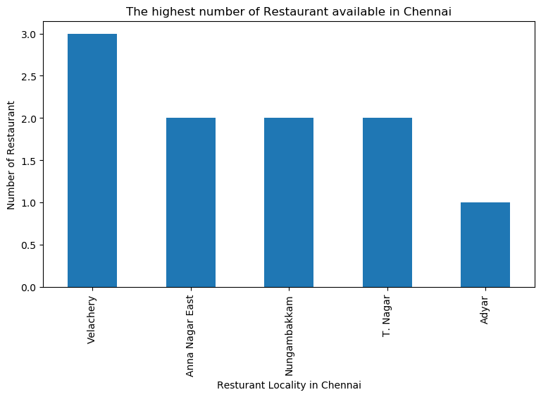

```python
import matplotlib.pyplot as plt
plt.figure(figsize=(9,5), dpi = 100)
# title
plt.title('The highest number of Restaurant available in Chennai')
#On x-axis

#giving a bar plot
df_tn_1.groupby('Neighborhood')['Restaurant Name'].count().nlargest().plot(kind='bar')

plt.xlabel('Resturant Locality in Chennai')
#On y-axis
plt.ylabel('Number of Restaurant')

#displays the plot
plt.show()
```

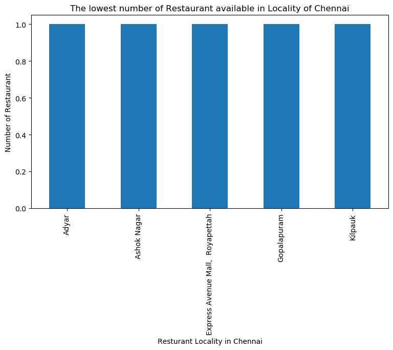

```python
plt.figure(figsize=(9,5), dpi = 100)
# title
plt.title('The lowest number of Restaurant available in Locality of Chennai')
#On x-axis

#giving a bar plot
df_tn_1.groupby('Neighborhood')['Restaurant Name'].count().nsmallest().plot(kind='bar')

plt.xlabel('Resturant Locality in Chennai')
#On y-axis
plt.ylabel('Number of Restaurant')

#displays the plot
plt.show()
```

[figure not shown]

```python
plt.figure(figsize=(9,5), dpi = 100)
# title
plt.title('The lowest number of Chinese Restaurant available in Locality of Chennai')
#On x-axis

#giving a bar plot
chennai_onehot.groupby('Neighborhood')['Chinese Restaurant'].count().nsmallest().plot(kind='bar')

plt.xlabel('Resturant Locality in Chennai')
#On y-axis
plt.ylabel('Number of Chinese Restaurant')

#displays the plot
plt.show()
```

[figure not shown]

```python
plt.figure(figsize=(9,5), dpi = 100)
# title
plt.title('The total number of Chinese Restaurant available in Locality of Chennai')
#On x-axis

#giving a bar plot
chennai_onehot.groupby('Neighborhood')['Chinese Restaurant'].count().plot(kind='bar')

plt.xlabel('Resturant Locality in Chennai')
#On y-axis
plt.ylabel('Number of Chinese Restaurant')
plt.ylim(0,50)

#displays the plot
plt.show()
```

[figure not shown]

```python
plt.figure(figsize=(9,5), dpi = 100)
# title
plt.title('The  rating of restaurants available in Locality of Chennai')
#On x-axis

#giving a bar plot
df_tn_1.groupby('Neighborhood')['Aggregate rating'].count().plot(kind='bar')

plt.xlabel('Resturant Locality in Chennai')
#On y-axis
plt.ylabel('Number of  Restaurant')
plt.ylim(0,5)

#displays the plot
plt.show()
```

[figure not shown]

```python
plt.figure(figsize=(9,5), dpi = 100)
# title
plt.title('The total number of  Restaurant with Online delivery available in Locality of Chennai')
#On x-axis

#giving a bar plot
df_tn_1.groupby('Neighborhood')['Has Online delivery'].count().plot(kind='bar')

plt.xlabel('Resturant Locality in Chennai')
#On y-axis
plt.ylabel('Number of  Restaurant')
plt.ylim(0,10)

#displays the plot
plt.show()
```